# Math 120 Lab 04 - Exploring Probability Distributions

24 October, 2019

## Part 1 Intro: Using The Distros

For each scenario, you’ll need to address the following:

- Which distribution (if any!) can be used to answer the question.
- A discussion of why the properties/requirements of the distribution are satisfied (for example, binomial RVs must satistfy four criteria described in Lec 13).
- The expected value, variance, and standard deviation for the distro, and a brief explanation of what they mean. You might need to consult the book or the internet (like Wikipedia!) for this.
- A plot of the distribution.
- The probability in question. Here, you’ll use the appropriate pdf or cdf. Include a brief explanation of how you computed the probability and what it means.
- A discussion about whether the event in question is “unusual”. The expected value and variance should feature prominently in this discussion. You may use, as a rule of thumb, that observations which are more than two standard deviations away from the expected value are “unusual”. The graph of the distribution could also be a good reference…
- If the scenario **doesn’t match** any of the probability distributions we’ve learned (binomial, geometric, or poisson), then write a brief explanation of why not.

### Scenario 1 - Geometric Distro

1. A machine that produces a special type of transistor (a component of computers) has a 2% defective rate. The production is considered a random process where each transistor is independent of the others. You are performing quality control, and investigate the transistors made by the machine until you find a defective one. What’s the probability that you have to look at more than 20 transistors before you find the first defect?

#### Solution

Here, $X$ counts the number of trials until the first success. Thus, $X$ is geometric. We note that each trial has only success or failure, the trials are independent, and the probability of success in constant for each trial.

We observe that $p=.02$, and thus $P(X>20)$ is found:

```r
1-pgeom(20,.02)    #There's a subtle lie here.  ;D
```

```
## [1] 0.6542558
```

The geometric dist has mean $\frac{1}{p}$, thus our expected value is 1/.02 = 50 trials. The variance is $\frac{1-p}{p^2}$, thus our standard deviation is

```r
sqrt((1-.02)/(.02^2))
```

```
## [1] 49.49747
```

We can see those features directly on the distribution:

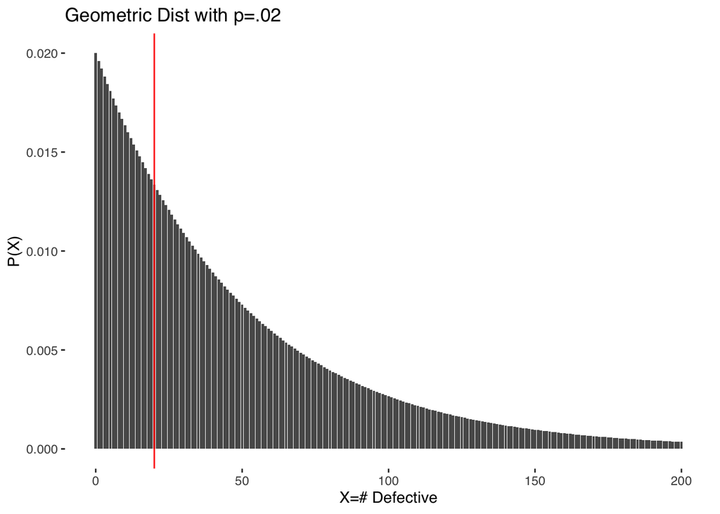

```r
qplot(0:200, dgeom(0:200,.02), geom="col", xlab="X=# Defective", ylab="P(X)", main="Geometric Dist with p=.02")+geom_vline(xintercept=20, color="red")
```

It’s clear from the above that our event, $X>20$ is not unusual (look at the red line).

### Scenario 2 - Normal Distro

2. Heights of 10 year olds, regardless of gender, closely follow a normal distribution with mean 55 inches and standard deviation 6 inches. What is the probability that a randomly chosen 10 year old is between 60 and 65 inches?

#### Solution

The distribution, center, and spread are all given.

```r
pnorm(65,55, 6)-pnorm(60,55,6)
```

```
## [1] 0.154538
```

Thus, there’s a 15.45% chance that a rando 10-year-old is between 60" and 65" tall. This falls within 2 standard deviations of the mean, and thus isn’t an unusual occurance.

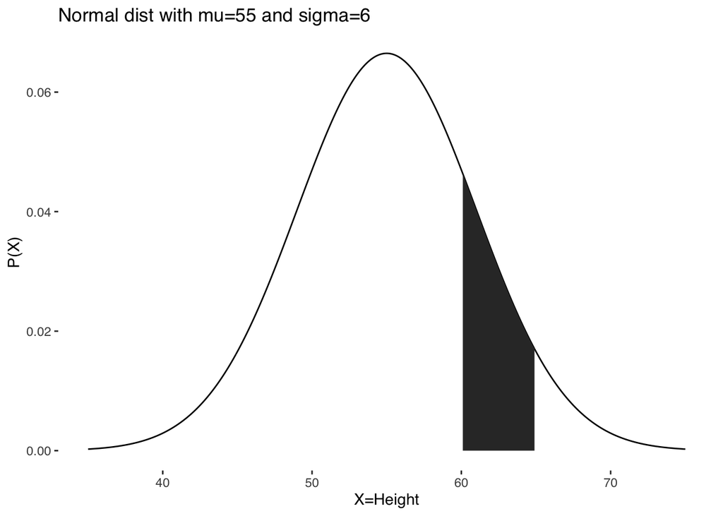

```r
xMin <- 35      #<-- far left boundary of graph
yMin <- 75      #<-- far right boundary of the graph
mu   <- 55      #<-- the mean for your dist
stdev<- 6       #<-- the stdev of your dist
shadedMin <-60  # where your shading starts
shadedMax <- 65 # where your shading ends

####Don't change the stuff below here! Play with the stuff above!
###################################################################

X = seq(xMin,yMin,.1)   # These are x-vals, can change limits (not .1)
P = dnorm(X, mu, stdev)

normalData = data.frame(X,P)    #need to use a dataframe for qplot

qplot(X,P, data=normalData, geom="line") +
  geom_area(data=subset(normalData, X>shadedMin & X<shadedMax), aes(ymax=P))+labs(x="X=Height", y="P(X)", title="Normal dist with mu=55 and sigma=6")
```

### Scenario 3 - Poisson Distro

3. Occasionally an airline will lose a bag. An analysis of customer records at a particular airline reveals that, on average, 2.2 bags are lost each day. Assuming that this rate is constant, what’s the probability that the airline loses at least 7 bags in the next day?

#### Solution

Here, X counts the number of occurences over an interval of time; thus $X$ is Poisson with $\lambda=2.2$.

We calculate $P(X\geq 7)$:

```r
1-ppois(6,2.2)
```

```
## [1] 0.007461346
```

The mean of the Poisson is just $\lambda=2.2$, and its standard deivation is $\sqrt{\frac{1}{\lambda} }$ = 0.6741999. Since $X>=7$ is many standard devitions away from the mean, it’s clear that this is an unusual event.

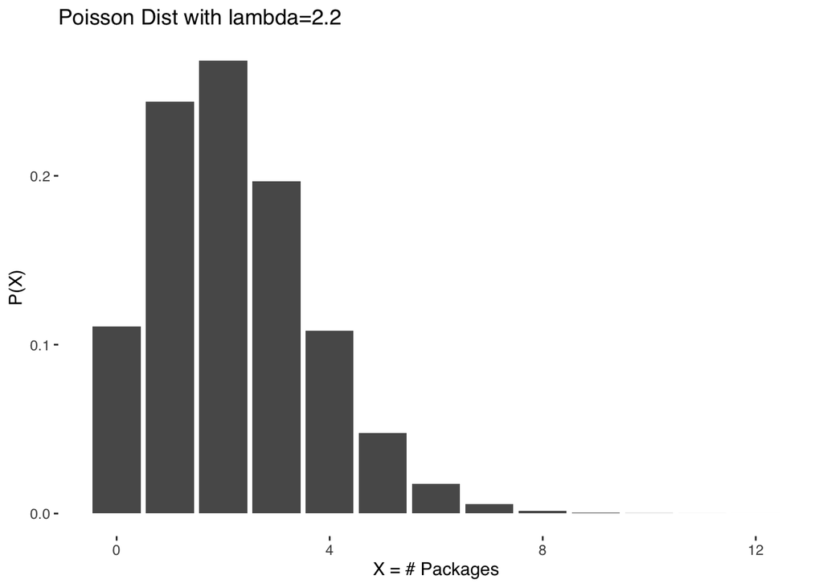

```r
xMin <- 0
xMax <- 12
lambda <- 2.2

##Don't mess with the plot below, except for labels.

qplot(xMin:xMax, dpois(xMin:xMax, lambda), geom="col")+
labs(x="X = # Packages", y="P(X)", title="Poisson Dist with lambda=2.2")
```

### Scenario 4 - Nietzsche’s Distro

4. In a videogame, “Green” level prizes are special, rare rewards for defeating an enemy. The chance of obtaining green level prizes after defeating an enemy is 12% by default, but if you *do* get a green prize, the chance of obtaining another green item is cut in half for 5 minutes. If you defeat 20 enemies in the game, what’s the chance you’ll be rewarded with at least two green prizes?

#### Solution

Since the chance of success changes from trial to trial, this scenario isn’t described by any of our probability distrutions.

### Scenario 5 - Uniform Distro

5. In a board game, player actions are determined by a spinner labelled like a clock, with values ranging from zero (at the top) all the way around to 12 (at the top again). Any value in between is equally likely, and a scale is provided on the spinner to see. For example, it’s just as likely to get 4.52 as 2.145 as 10.9924. You need to spin a number bewtween 6 and 7 to win the game on this turn. What’s the probability that happens?

#### Solution

This is a continuous variable with equal likelihood across its support; i.e., this is a uniform distro ranging from 0 to 12. We calculate $P(6\leq X \leq 7)$:

```r
punif(7,0,12)-punif(6,0,12)
```

```
## [1] 0.08333333
```

The center of the uniform distro is $\frac{b+a}{2}=6$ , and its standard deviation is $\frac{1}{12}(b-a)^2=12$. Thus, our event is quite common and falls within one standard deviation of the mean. See below:

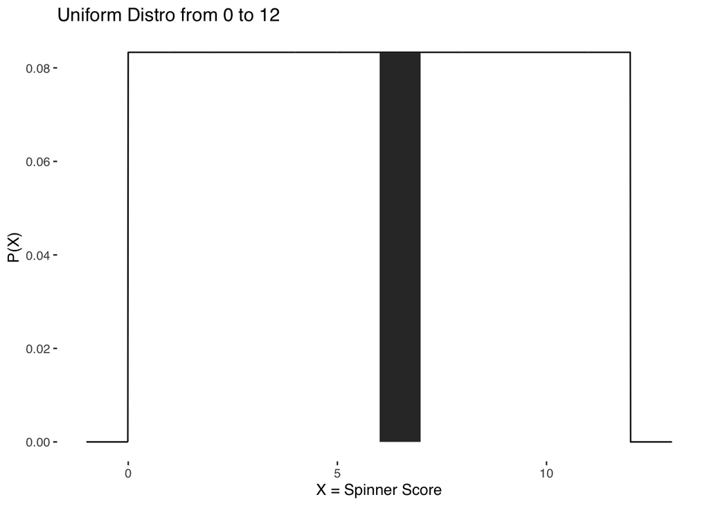

```r
xMin <- -1        #<-- far left boundary of graph
yMin <- 13         #<-- far right boundary of the graph
uniformMin <- 0  # the low bound for your dist
uniformMax <- 12  # the high bound for your dist
shadedMin <-6     # where your shading starts
shadedMax <- 7    # where your shading ends


####Don't change the stuff below here! Play with the stuff above!

X = seq(xMin,yMin,.01)    # These are x-vals, can change limits (not .1)
P = dunif(X, uniformMin, uniformMax)

normalData = data.frame(X,P)       #need to use a dataframe for qplot

qplot(X,P, data=normalData, geom="line") +
  geom_area(data=subset(normalData, X>shadedMin & X<shadedMax), aes(ymax=P))+
  labs(x="X = Spinner Score", y="P(X)", title="Uniform Distro from 0 to 12")
```

### Scenario 6: Binomial Distro

6. Data collected by the Substance Abuse and Mental Health Services Administration (SAMSHA) suggests that 69.7% of 18-20 year olds consumed alcoholic beverages in any given year. We now consider a random sample of fifty 18-20 year olds. Would you be surprised if there were 45 or more people who have consumed alcoholic beverages?

#### Solution

Since $X$ counts the number of successes out of a fixed number of trials ($n=50$), it’s binomial. Note that each trial has two outcomes, constant prob of success ($p=.697$), and we may assume independence due to a large population.

We calculate $P(X\geq 45)$:

```r
1-pbinom(44, 50, .697)
```

```
## [1] 0.0006236641
```

The binomial has mean $np$ =34.85 and standard deviation $\sqrt{np(1-p)}$ = 3.2495461. Thus it would be very unusual for 45 or more to have consumed alchohol, as this outcome is several standard deviations above the mean.

## Part II: Sampling and Simulation

### The Dice Distro

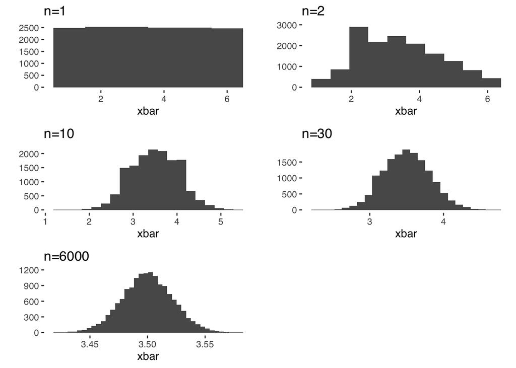

```r
mysamples1 <- replicate(15000, mean(sample(1:6, 1, replace = TRUE)))

p1 <- qplot(mysamples1, geom="histogram", bins=6)+labs(x="xbar", title="n=1")


mysamples2 <- replicate(15000, mean(sample(1:6, 2, replace = TRUE)))

p2 <- qplot(mysamples2, geom="histogram", bins=10)+labs(x="xbar", title="n=2")


mysamples3 <- replicate(15000, mean(sample(1:6, 10, replace = TRUE)))

p3 <- qplot(mysamples3, geom="histogram", bins=20)+labs(x="xbar", title="n=10")


mysamples4 <- replicate(15000, mean(sample(1:6, 30, replace = TRUE)))

p4 <- qplot(mysamples4, geom="histogram", bins=25)+labs(x="xbar", title="n=30")


mysamples5 <- replicate(15000, mean(sample(1:6, 6000, replace = TRUE)))

p5 <- qplot(mysamples5, geom="histogram", bins=40)+labs(x="xbar", title="n=6000")

grid.arrange(p1,p2,p3,p4,p5)
```

For n=1, we’re essentially seeing original population. Makes sense: all the numbers are equally likely! As our sample size increases, we see a normal shape.

### The Iris Data

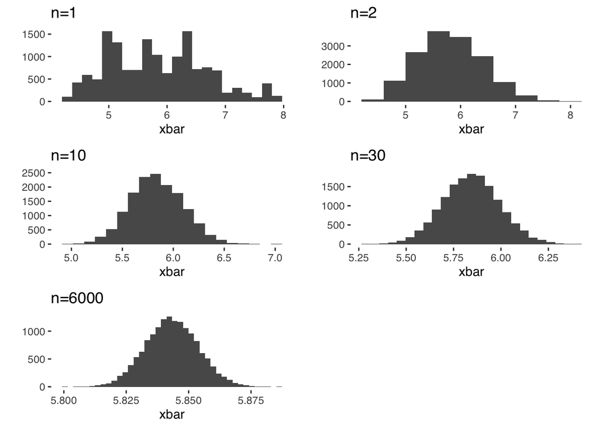

```r
mysamples1 <- replicate(15000, mean(sample(iris$Sepal.Length, 1, replace = TRUE)))

p1 <- qplot(mysamples1, geom="histogram", bins=22)+labs(x="xbar", title="n=1")


mysamples2 <- replicate(15000, mean(sample(iris$Sepal.Length, 2, replace = TRUE)))

p2 <- qplot(mysamples2, geom="histogram", bins=10)+labs(x="xbar", title="n=2")


mysamples3 <- replicate(15000, mean(sample(iris$Sepal.Length, 10, replace = TRUE)))

p3 <- qplot(mysamples3, geom="histogram", bins=20)+labs(x="xbar", title="n=10")


mysamples4 <- replicate(15000, mean(sample(iris$Sepal.Length, 30, replace = TRUE)))

p4 <- qplot(mysamples4, geom="histogram", bins=25)+labs(x="xbar", title="n=30")


mysamples5 <- replicate(15000, mean(sample(iris$Sepal.Length, 6000, replace = TRUE)))

p5 <- qplot(mysamples5, geom="histogram", bins=40)+labs(x="xbar", title="n=6000")

grid.arrange(p1,p2,p3,p4,p5)
```

We see the same drama here: the original populaiton is unruly, but the sample averages follow a predictable bell-shaped pattern.

### The Poisson Distro

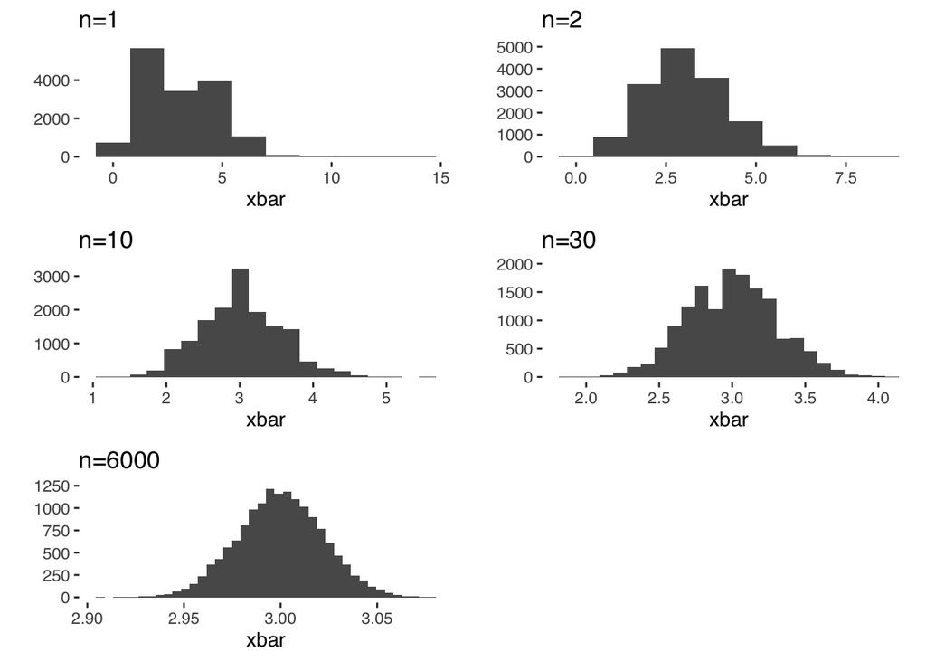

```r
mysamples1 <- replicate(15000, mean(rpois(1,3)))

p1 <- qplot(mysamples1, geom="histogram", bins=10)+labs(x="xbar", title="n=1")


mysamples2 <- replicate(15000, mean(rpois(2,3)))

p2 <- qplot(mysamples2, geom="histogram", bins=10)+labs(x="xbar", title="n=2")


mysamples3 <- replicate(15000, mean(rpois(10,3)))

p3 <- qplot(mysamples3, geom="histogram", bins=20)+labs(x="xbar", title="n=10")


mysamples4 <- replicate(15000, mean(rpois(30,3)))

p4 <- qplot(mysamples4, geom="histogram", bins=25)+labs(x="xbar", title="n=30")


mysamples5 <- replicate(15000, mean(rpois(6000,3)))

p5 <- qplot(mysamples5, geom="histogram", bins=40)+labs(x="xbar", title="n=6000")

grid.arrange(p1,p2,p3,p4,p5)
```

Even though the Poisson distro is highly right-skew, its sampling distirbution has a predictable bell-curve pattern.